# Processing evaluation RMassBank

## Including Plots

EIC with associated triggered MS/MS, per compound

## 153 Dazomet

mz = 163.0358 (OK)

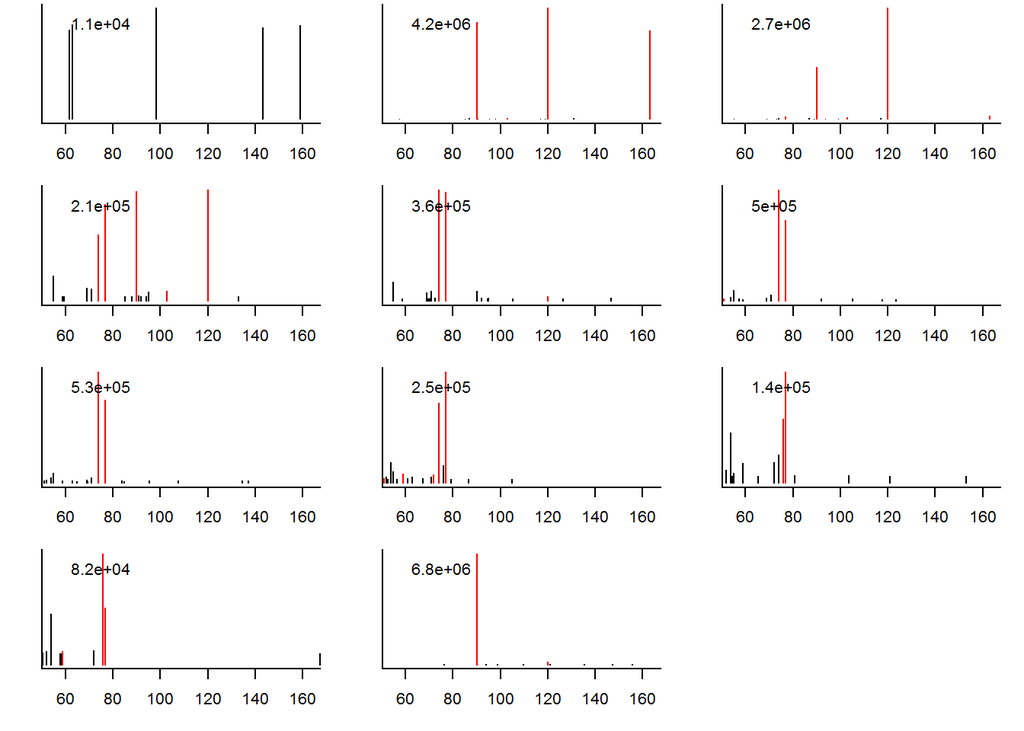

## 4091 Dithianon

mz = 296.9787 (OK)

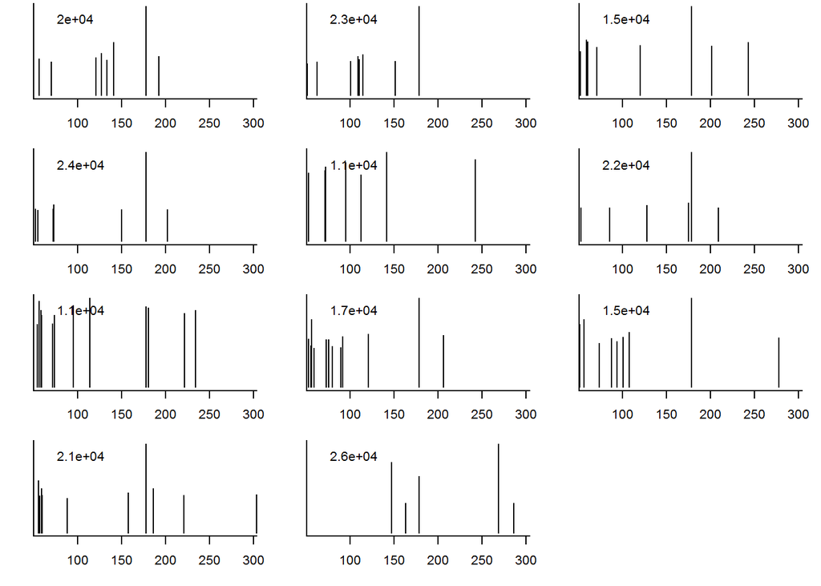

## 4094 Acequinocyl

mz = 385.2373 (OK)

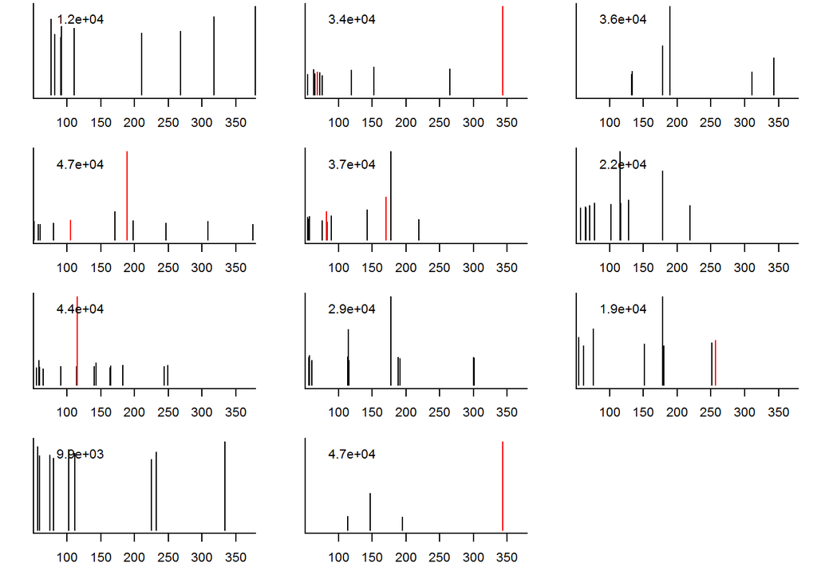

## 4097 Daminozide

mz = 161.0921 (OK)

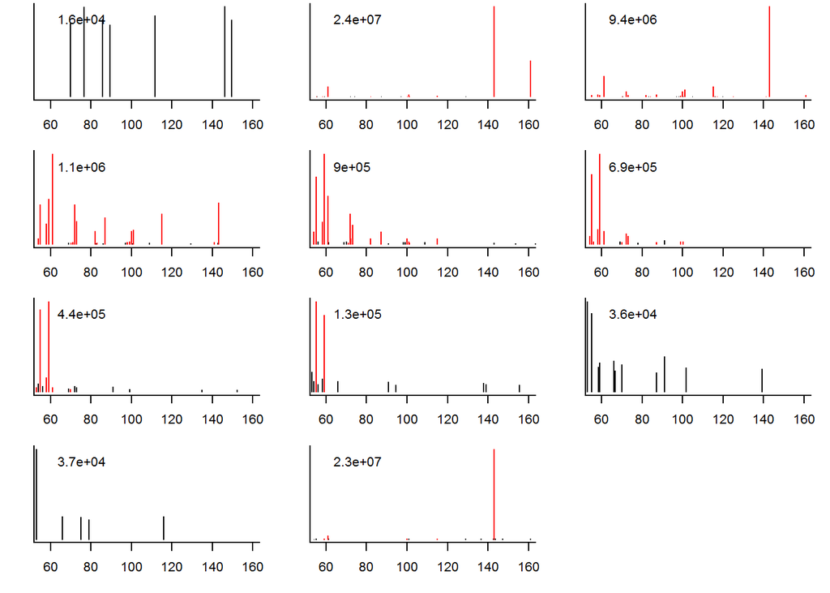

## 4128 Acetylcystein

mz = 164.0376 (OK)

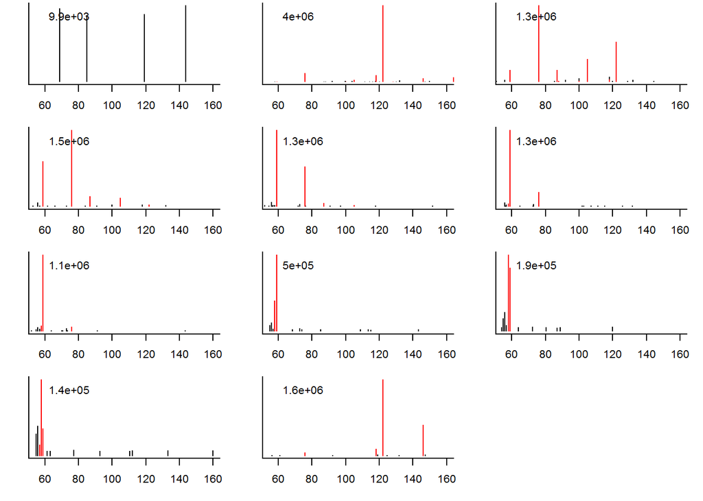

## 4135 Cysteamine

mz = (not found)

## 3594 Avermectin B1a

mz = 873.4995 (OK)

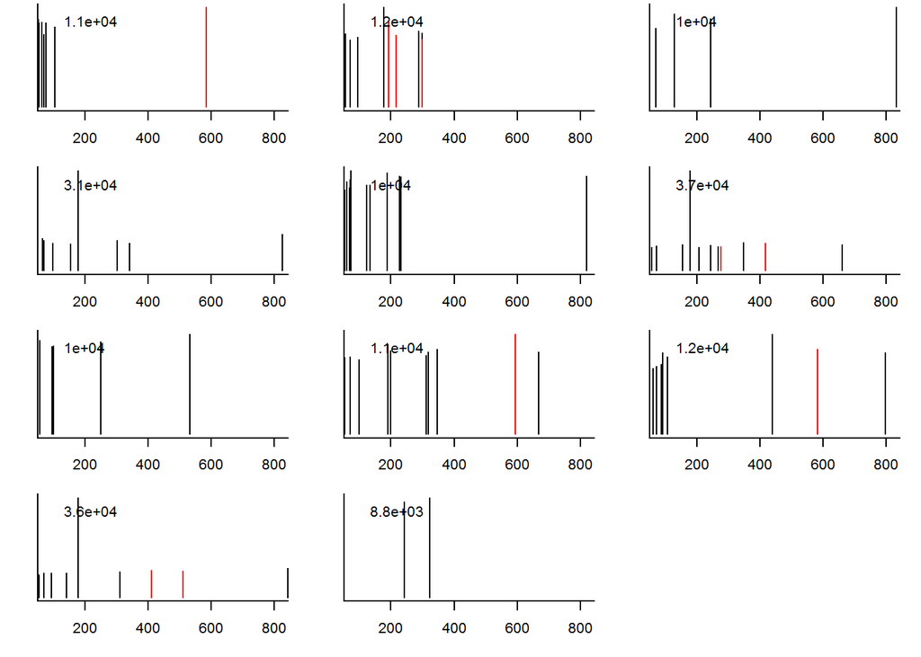

## 4129 Econazole nitrate

mz = 381.0323 (OK)

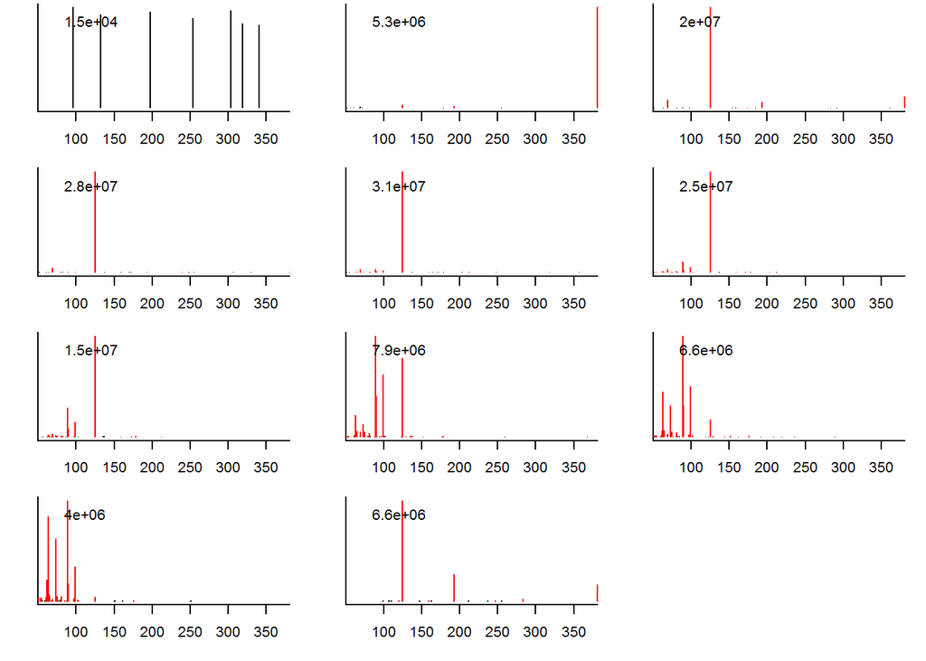

## 4095 Aminopyralid

mz = 206.9723 (OK)

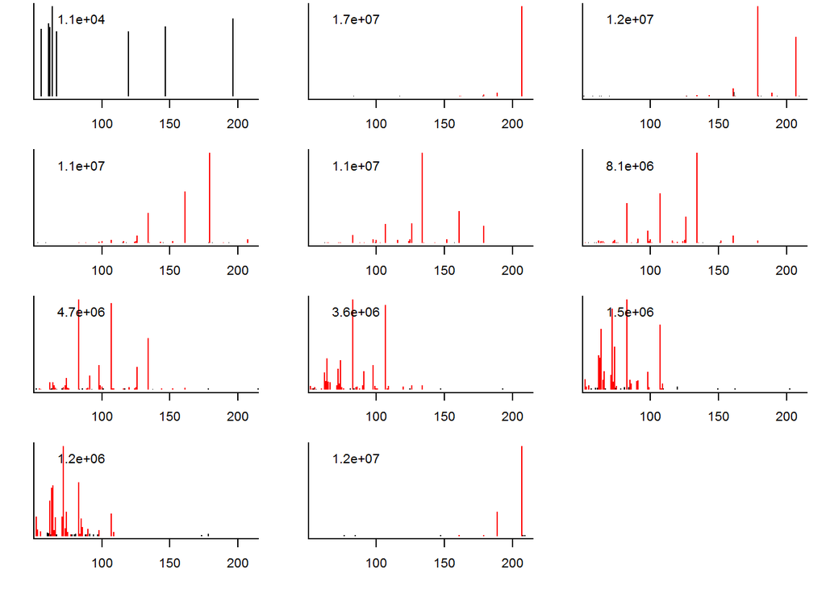

## 9999 Spinosad (Spinosyn A&D)

mz = 732.4681 (OK)

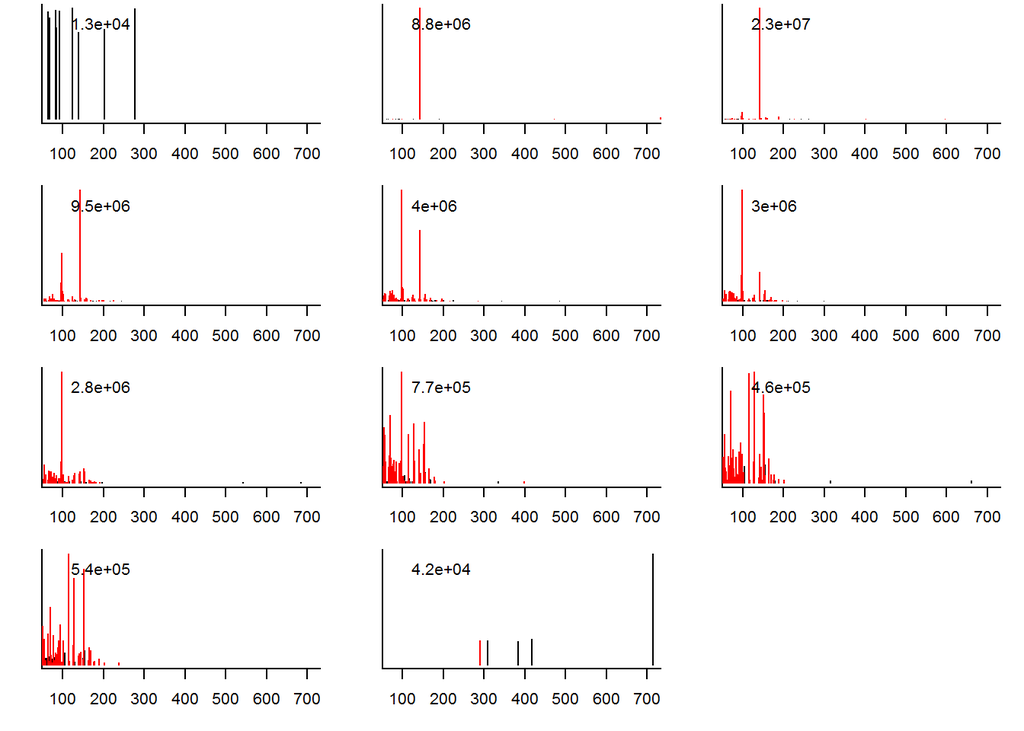

## 3828 Triadimenol A

mz = 296.116 (OK)

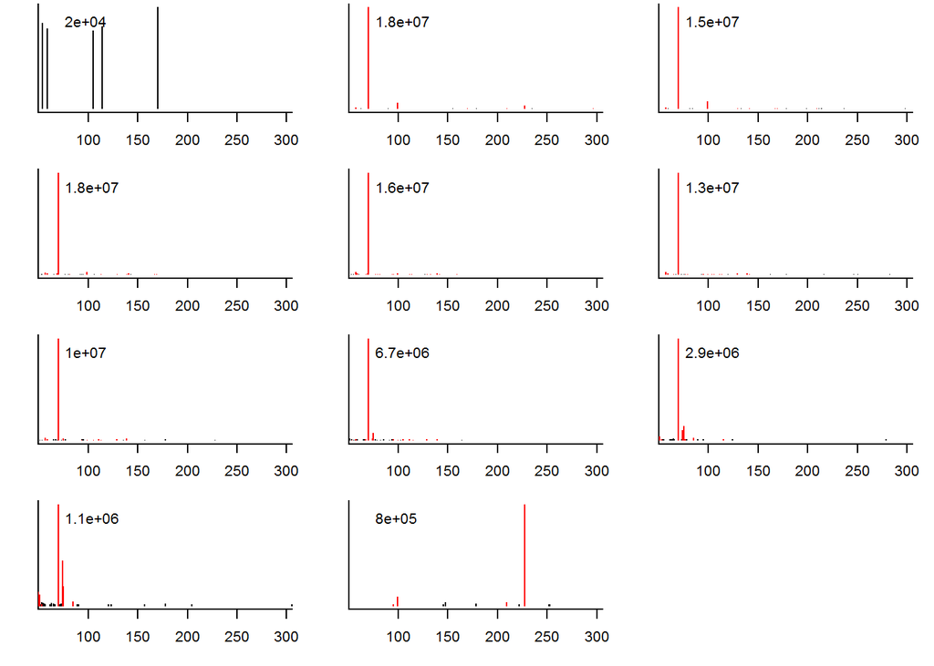

## 3800 Metaldehyde

mz = (not found)

## 109 Bifenox-Säure

mz = 327.9774 (OK)

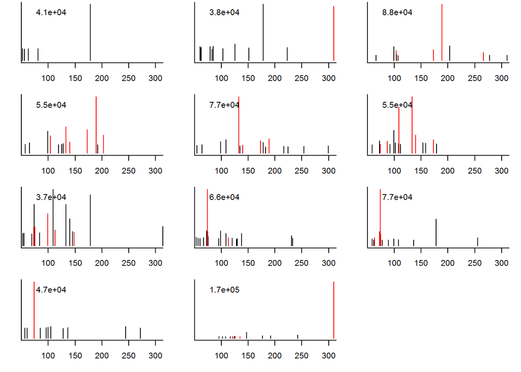

## 291 Sulcotrion-CMBA

mz = 234.9826 (OK)

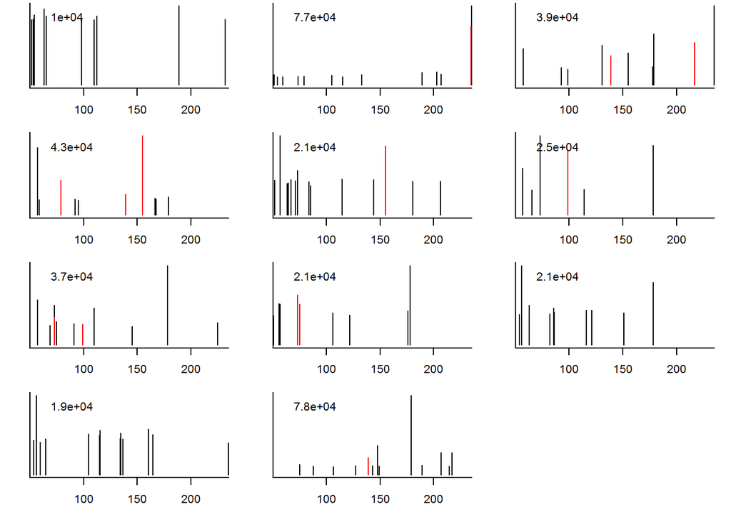

## 3502 Acibenzolar-S-methyl

mz = (not found)

## 3522 Fenpyroximate

mz = 422.2074 (OK)

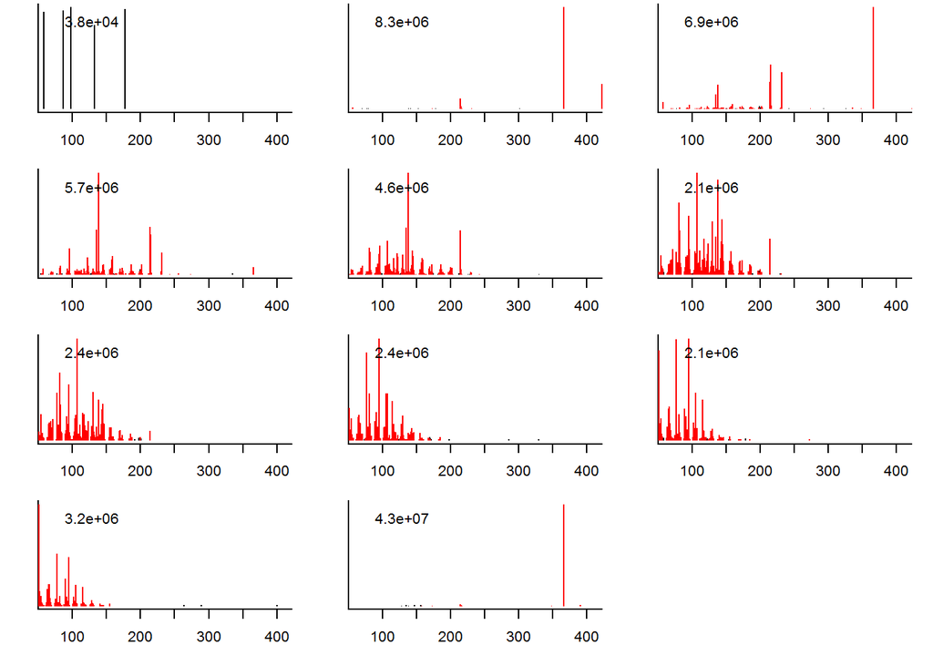

## 3543 Carfentrazone-ethyl

mz = 412.0437 (OK)

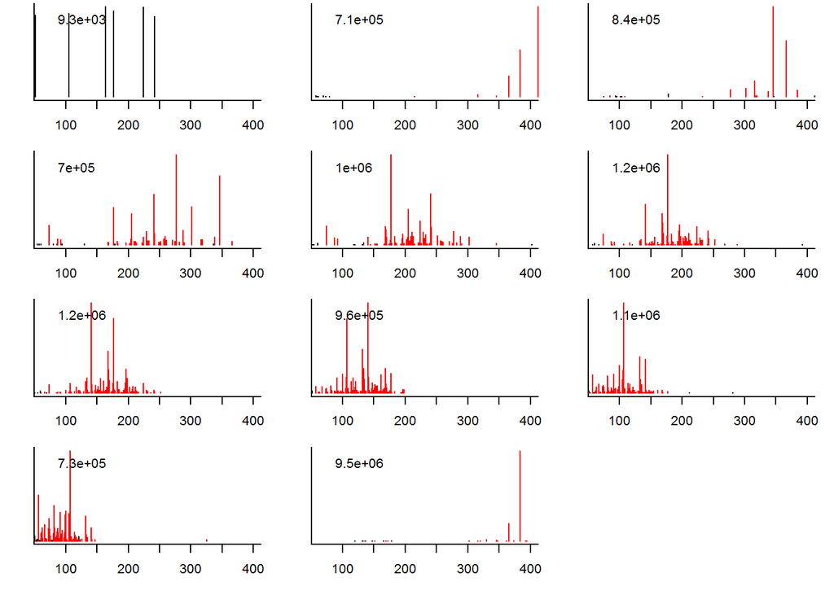

## 3549 Flurochloridon

mz = 312.0164 (OK)

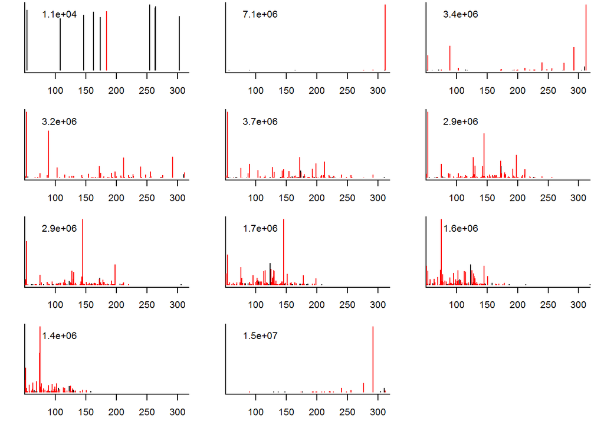

## 3577 1-Naphthylaceticacid

mz = 187.0754 (OK)

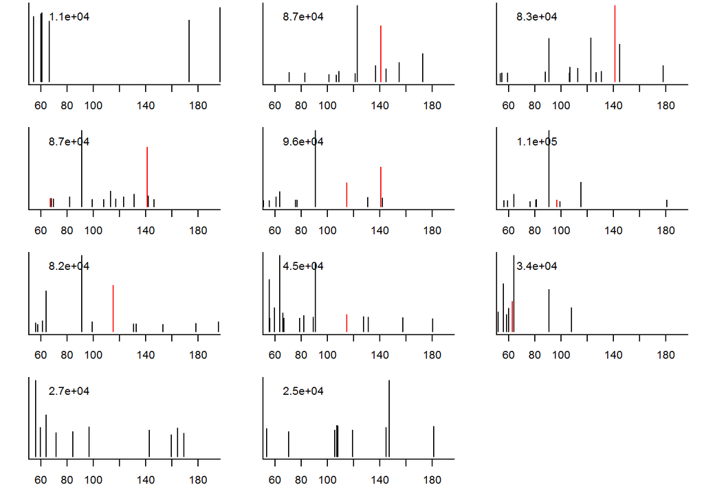

## 3812 Cloquintocet-mexyl

mz = 336.1361 (OK)

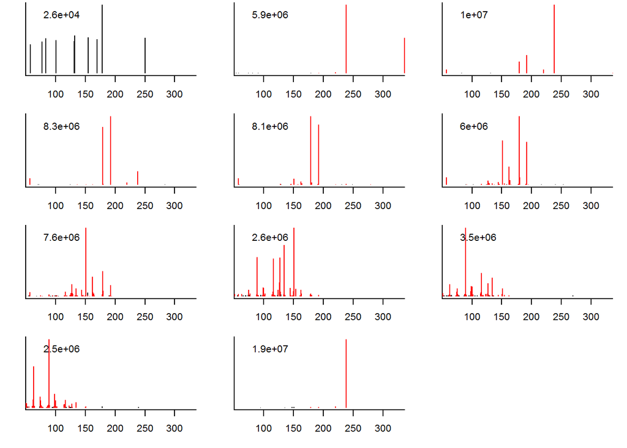

## 3813 Prothioconazole

mz = 344.0386 (OK)

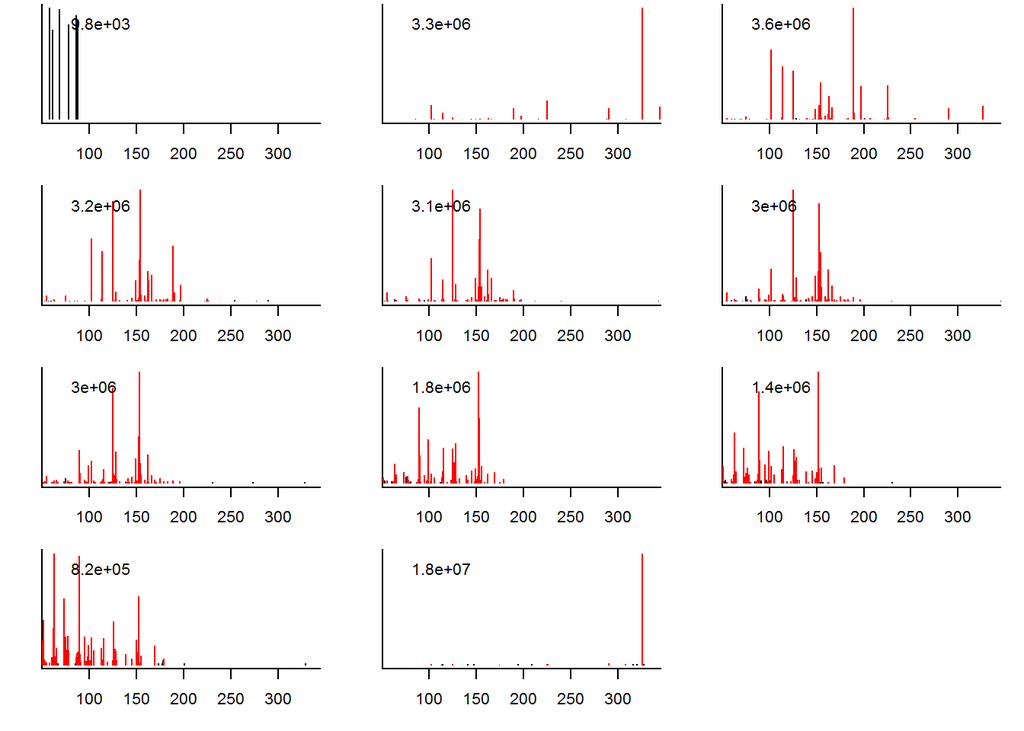

## 3814 Emamectin

mz = 886.5311 (OK)

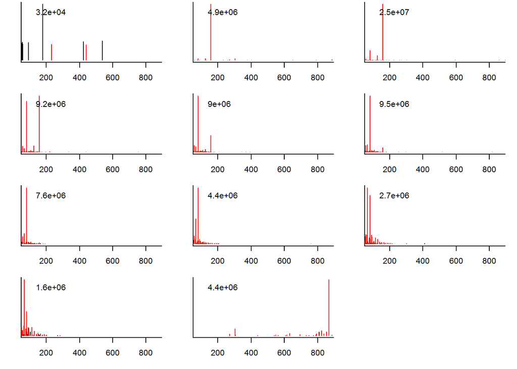

## 3815 Spirodiclofen

mz = 411.1124 (OK)

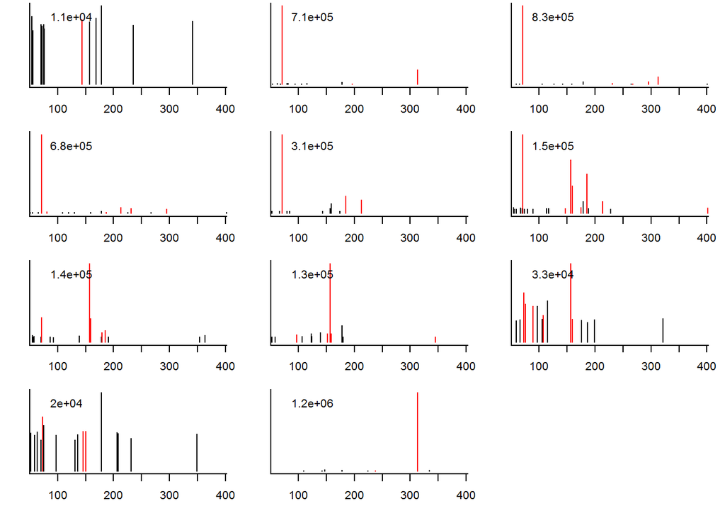

## 3816 Picoxystrobin

mz = 368.1104 (OK)

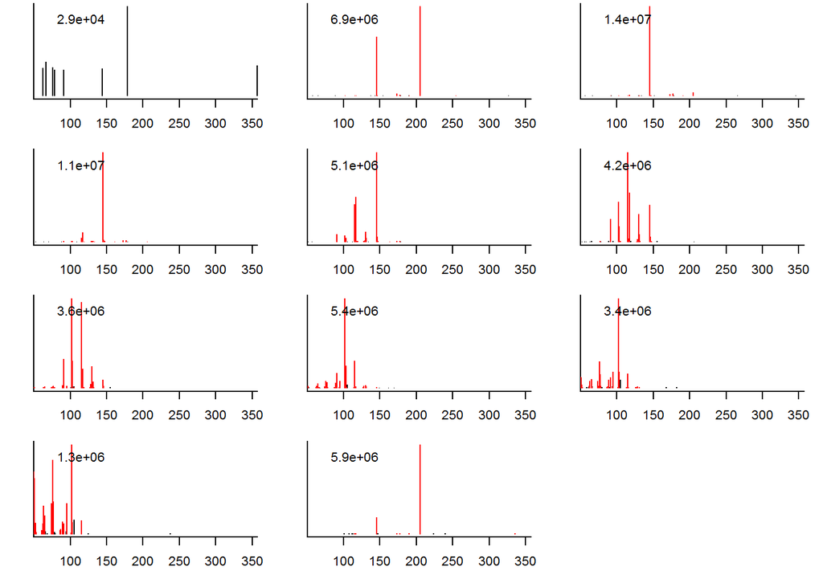

## 4092 Etoxazol

mz = 360.177 (OK)

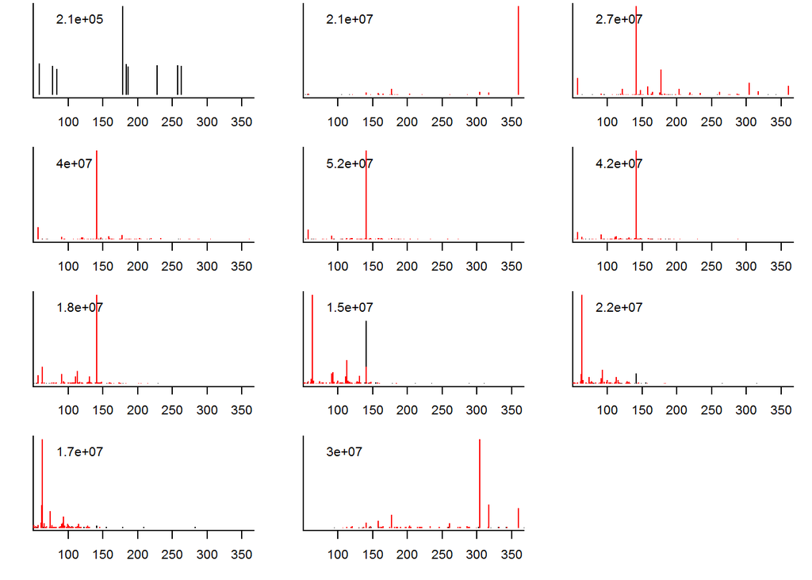

## 4093 Flazasulfuron

mz = 408.0584 (OK)

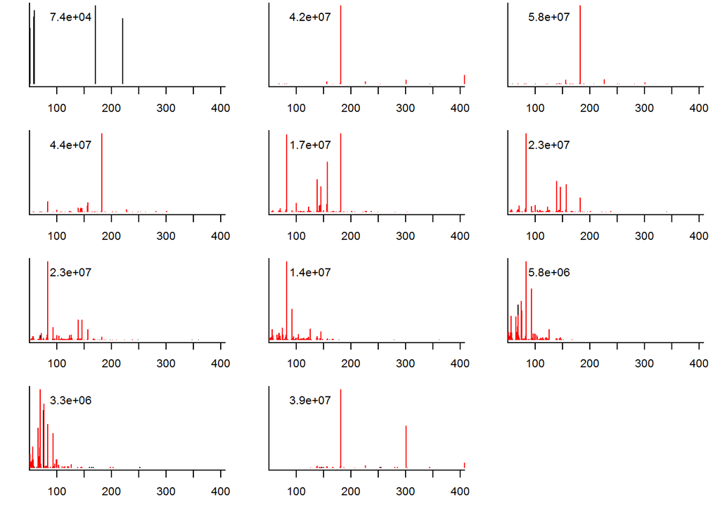

## 4096 alpha-Naphthylacetamid

mz = 186.0913 (OK)

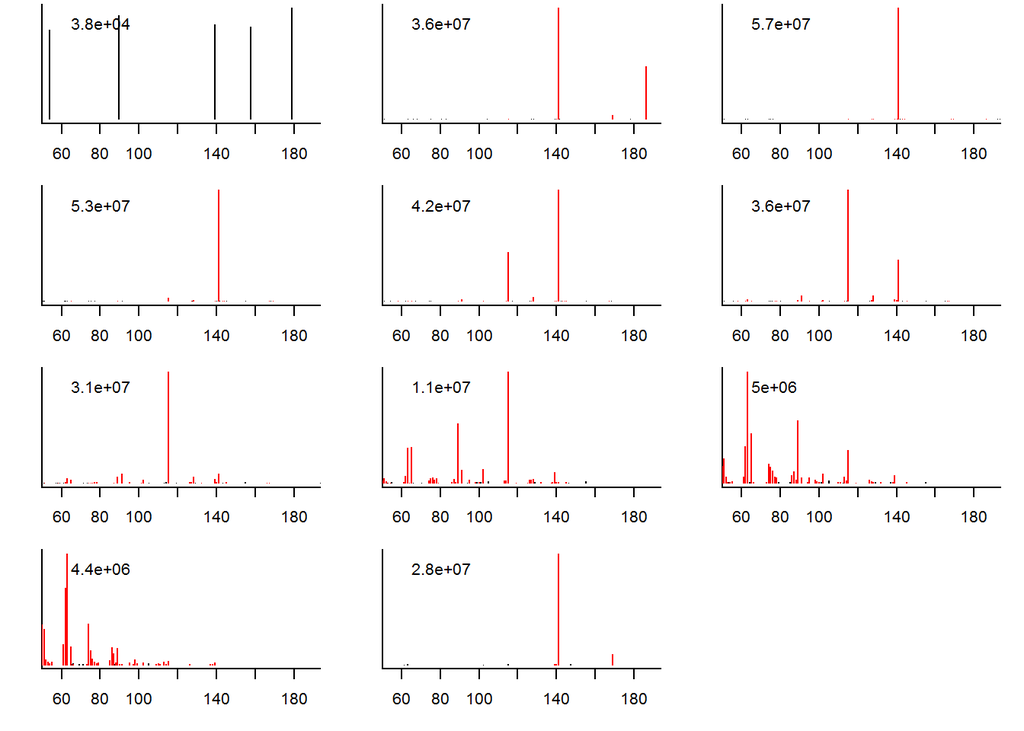

## 4098 Fenpyrazamin

mz = 332.1427 (OK)

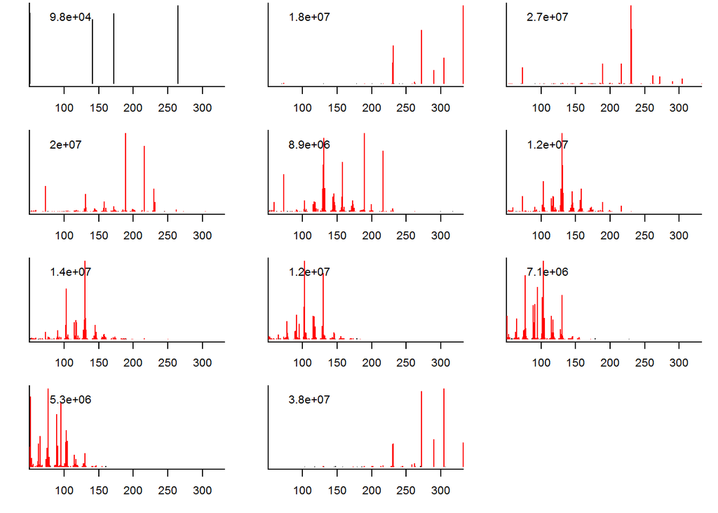

## 4101 Valifenalate

mz = 399.1681 (OK)

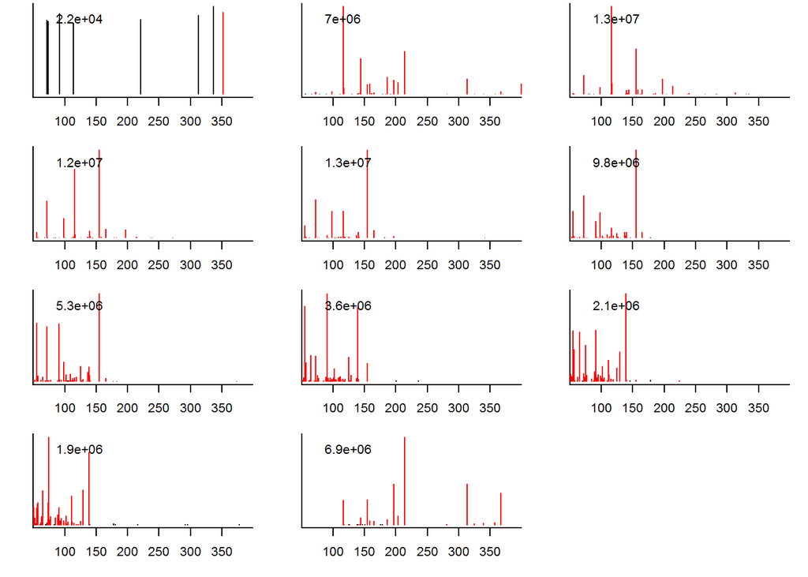

## 4102 Penoxsulam

mz = 484.0709 (OK)

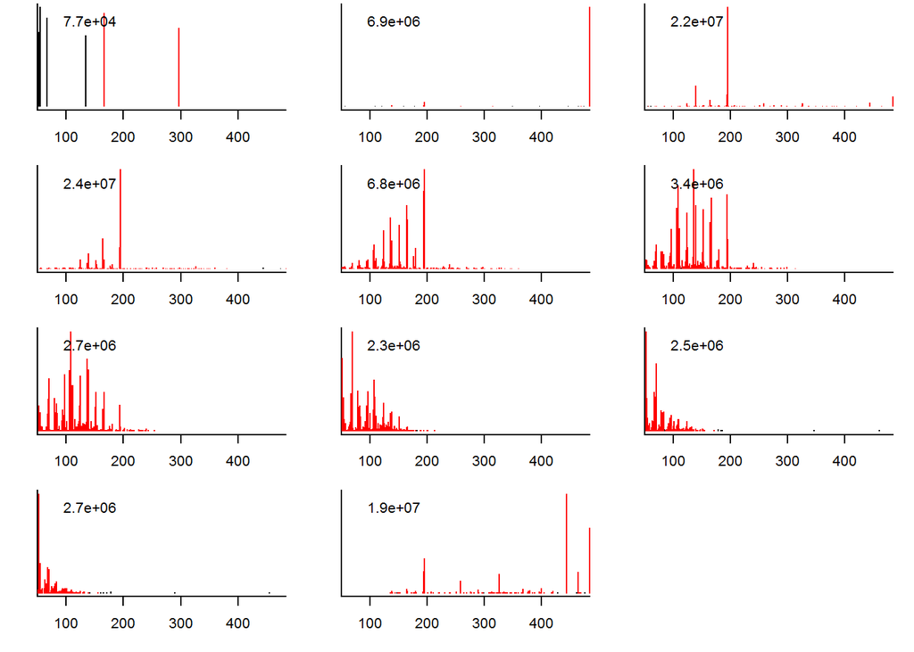

## 4103 Penthiopyrad

mz = 360.1352 (OK)

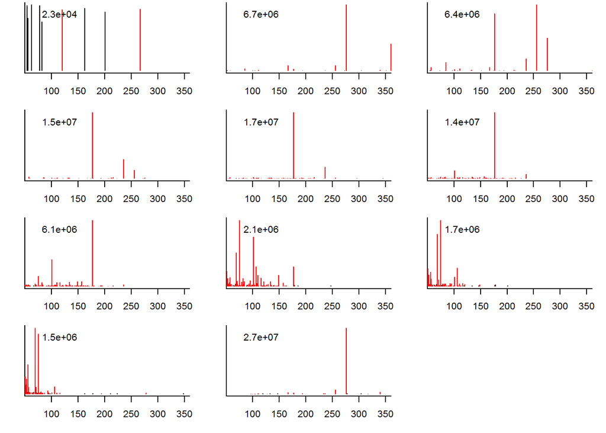

## 4104 Amisulbrom

mz = (not found)

## 4105 Fluxapyroxad

mz = 382.0973 (OK)

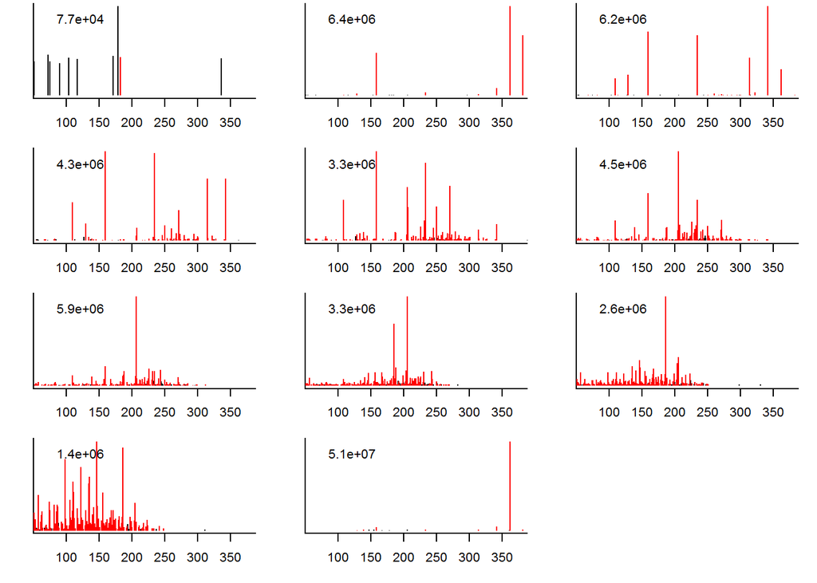

## 4106 6-Benzyladenine

mz = 226.1087 (OK)

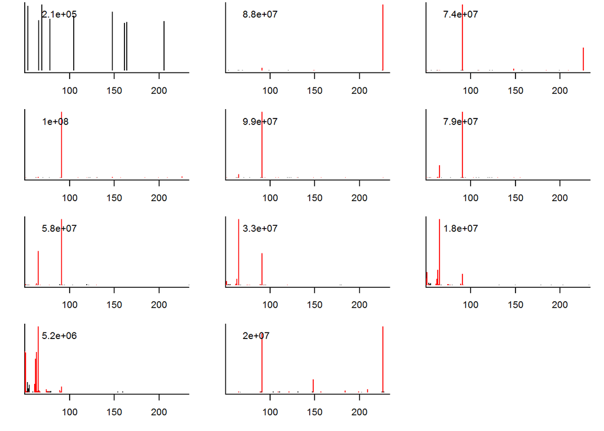

## 4141 Tetracarbonitrilpropen

mz = (not found)

## 4149 Everolimus

mz = (not found)

## 4144 Thiophenol

mz = (not found)

## 4145 3-(Trifluormethyl)anilin

mz = 162.0525 (OK)

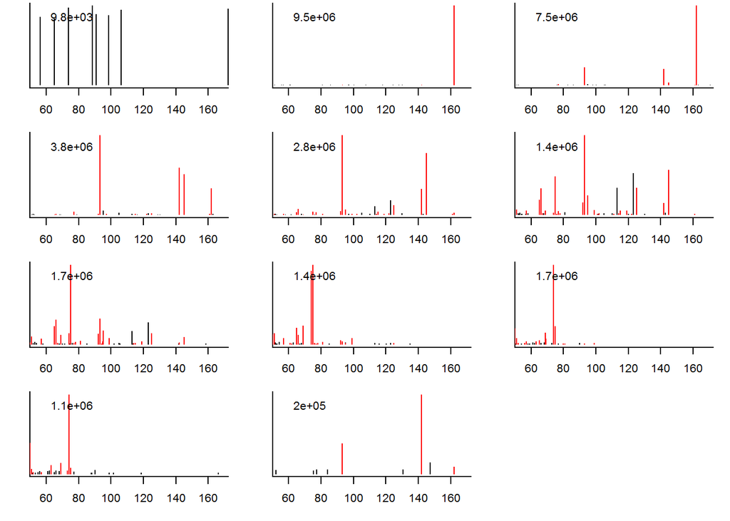

## 3819 AMPS

mz = 208.0638 (OK)

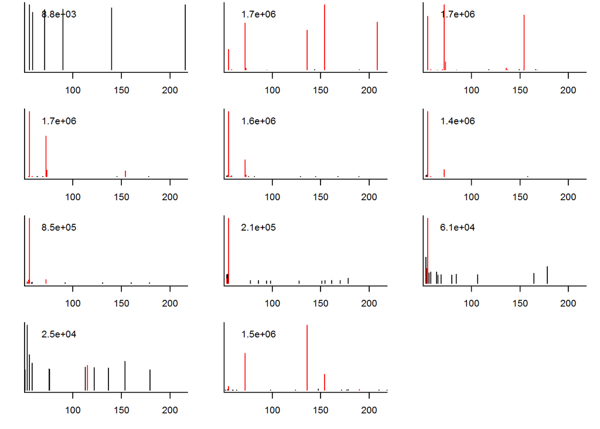